# R Beginners Course

## Isolating Cells with Particular Attributes

Now, we multiply the precipitation raster by the arid unitary raster and crop it to the *climate.zones* layer extent.

```r
arid.precipitation <- chirps * arid
arid.precipitation <- crop(arid.precipitation, climate.zones, snap = "out")
```

## Isolating Cells with Particular Attributes

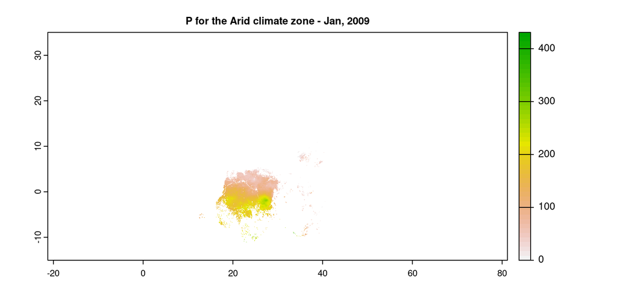

```r
plot(arid.precipitation, main = "P for the Arid climate zone - Jan, 2009")
```

## Isolating Cells with Particular Attributes

Finally, we want to obtain the mean precipitation for the arid climate zone.

- For this purpose, we will use the *values* function to extract the numeric values from the raster layer.
- Then we will use the *mean* function with the na.rm parameter set to TRUE.

```r
mean.arid <- mean(values(arid.precipitation), na.rm = TRUE)
print(mean.arid)
```

```
## [1] 132.4065
```

## Extracting Values from a Raster at Specific Coordinates

```r
longitude <- c(-100, -50, 20, 100, 117)
latitude  <- c(22, -20, -1, 0, -32)
lonlat    <- cbind(longitude, latitude)
print(lonlat)
```

```
##      longitude latitude
## [1,]      -100       22
## [2,]       -50      -20
## [3,]        20       -1
## [4,]       100        0
## [5,]       117      -32
```

## Extracting Values from a Raster at Specific Coordinates

Now we have to convert the coordinates to a SpatVector.

```r
locations <- vect(lonlat)
print(locations)
```

```
##  class       : SpatVector
##  geometry    : points
##  dimensions  : 5, 0  (geometries, attributes)
##  extent      : -100, 117, -32, 22  (xmin, xmax, ymin, ymax)
##  coord. ref. :
```

## Extracting Values from a Raster at Specific Coordinates

We can plot CHIRPS and the stations as follows:

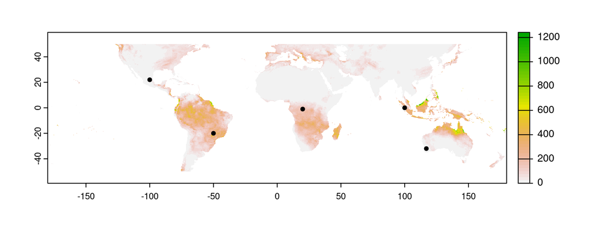

```r
plot(chirps)
points(locations)
```

## Extracting Values from a Raster at Specific Coordinates

To extract the values of the selected stations we will use the extract function.

```r
extraction <- terra::extract(chirps, locations)
extraction <- extraction[2:length(extraction)]
print(extraction)
```

```
##   chirps_monthly2009-01
## 1              6.863122
## 2            259.973359
## 3            183.161122
## 4            329.991304
## 5             16.177693
```

Because the function extract might be included in another package, the double semicolons (::) indicate the package that should be used. We can also use this extract function to extract time series from a multilayer object.